# Weight Lifting Exercise Analysis

khsarma

July 23, 2018

### Synopsis

In this project, your goal will be to use data from accelerometers on the belt, forearm, arm, and dumbell of 6 participants. They were asked to perform barbell lifts correctly and incorrectly in 5 different ways. We are going to quantify how well they did exercise.

### Import and Explore data set

```r
pmlTr <- read.csv("pml-training.csv", header = TRUE)
pmlVal <- read.csv("pml-testing.csv", header = TRUE)

dim(pmlTr) # 19622 observations of 160 features
```

```
## [1] 19622   160
```

```r
dim(pmlVal) # 20 observations
```

```
## [1]  20 160
```

We are going to consider testing csv file as validation set. Let’s create Training and Testing set out of training csv file.

```r
set.seed(2525)
pmlInTrain <- createDataPartition(y = pmlTr$classe, p = 0.6, list = FALSE)
pmlTrain <- pmlTr[pmlInTrain,]
pmlTest <- pmlTr[-pmlInTrain,]
```

### Feature selection

We are going to remove new-zero covariates and variables with higher number of NAs. Also, first 5 columns in the data set are not going to have any impact on the prodiction as there are user names, timestamps etc.

```r
# remove variables with nearly zero variance
nzv <- nearZeroVar(pmlTrain)
pmlTrain <- pmlTrain[, -nzv]
pmlTest <- pmlTest[, -nzv]

# remove variables that have high number of NAs
pmlNA <- sapply(pmlTrain, function(x) mean(is.na(x))) > 0.90
pmlTrain <- pmlTrain[, pmlNA == FALSE]
pmlTest <- pmlTest[, pmlNA == FALSE]

# remove first 5 columns
pmlTrain <- pmlTrain[, -(1:5)]
pmlTest <- pmlTest[, -(1:5)]
```

### Model Selection

Let’s use 2 popular bagging algorithms - Bagged CART and Random Forest. First, we’ll set up control parameter with ‘cv’ method for cross validation. We’ll use treebag and random forest methods to train and summarize our results.

```r
# Bagging algorithms
tc <- trainControl(method = "cv", number = 3)
# Bagged CART
set.seed(7)
modeltreebag <- train(classe~., data = pmlTrain, method = "treebag", metric = "Accuracy", trControl = tc)
# Random Forest
set.seed(7)
modelrf <- train(classe~., data = pmlTrain, method = "rf", metric = "Accuracy", trControl = tc)
# summarize results
results <- resamples(list(treebag = modeltreebag, rf = modelrf))
summary(results)
```

```
##
## Call:
## summary.resamples(object = results)
##
## Models: treebag, rf
## Number of resamples: 3
##
## Accuracy
##              Min.   1st Qu.    Median      Mean   3rd Qu.      Max. NA's
## treebag 0.9882832 0.9885365 0.9887898 0.9906592 0.9918471 0.9949045    0
## rf      0.9918492 0.9927399 0.9936306 0.9932916 0.9940127 0.9943949    0
##
## Kappa
##              Min.   1st Qu.    Median      Mean   3rd Qu.      Max. NA's
## treebag 0.9851740 0.9854963 0.9858185 0.9881823 0.9896865 0.9935545    0
## rf      0.9896866 0.9908151 0.9919437 0.9915132 0.9924266 0.9929095    0
```

It can be observed that random forest gave an accuracy of 99.33% and better than treebag bagging method.

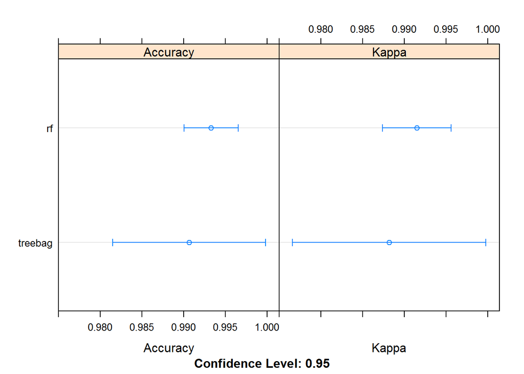

```r
dotplot(results)
```

### Prediction

#### With Random Forest

```r
predictrf <- predict(modelrf, pmlTest)
confusionMatrix(predictrf, pmlTest$classe)
```

```
## Confusion Matrix and Statistics
##
##           Reference
## Prediction    A    B    C    D    E
##          A 2231    2    0    0    0
##          B    1 1513    2    0    0
##          C    0    2 1360    9    0
##          D    0    1    6 1276    0
##          E    0    0    0    1 1442
##
## Overall Statistics
##
##                Accuracy : 0.9969
##                  95% CI : (0.9955, 0.998)
##     No Information Rate : 0.2845
##     P-Value [Acc > NIR] : < 2.2e-16
##
##                   Kappa : 0.9961
##  Mcnemar's Test P-Value : NA
##
## Statistics by Class:
##
##                      Class: A Class: B Class: C Class: D Class: E
## Sensitivity            0.9996   0.9967   0.9942   0.9922   1.0000
## Specificity            0.9996   0.9995   0.9983   0.9989   0.9998
## Pos Pred Value         0.9991   0.9980   0.9920   0.9945   0.9993
## Neg Pred Value         0.9998   0.9992   0.9988   0.9985   1.0000
## Prevalence             0.2845   0.1935   0.1744   0.1639   0.1838
## Detection Rate         0.2843   0.1928   0.1733   0.1626   0.1838
## Detection Prevalence   0.2846   0.1932   0.1747   0.1635   0.1839
## Balanced Accuracy      0.9996   0.9981   0.9962   0.9956   0.9999
```

Thus, accuracy is 99.7% and out of sample erroris 0.3%.

#### Making Test set prediction

Before making Test set prediction we have to re-fit the model on the complete Train set.

```r
# remove variables with nearly zero variance
nzv <- nearZeroVar(pmlTr)
pmlTraining <- pmlTr[, -nzv]
pmlTesting <- pmlVal[, -nzv]

# remove variables that have high number of NAs
pmlNA <- sapply(pmlTraining, function(x) mean(is.na(x))) > 0.90
pmlTraining <- pmlTraining[, pmlNA == FALSE]
pmlTesting <- pmlTesting[, pmlNA == FALSE]

# remove first 5 columns
pmlTraining <- pmlTraining[, -(1:5)]
pmlTesting <- pmlTesting[, -(1:5)]

# train using complete training set
fitControl <- trainControl(method="cv", number=3, verboseIter=F)
refit <- train(classe ~ ., data=pmlTraining, method="rf", trControl=fitControl)

# Predict using the actual test set
predictTest <- predict(refit, newdata = pmlTesting)
predictTest
```

```
##  [1] B A B A A E D B A A B C B A E E A B B B
## Levels: A B C D E
```